# HW 06 Part 2: Wrangle II

Donovan Kleinberg

30 December 2018

```r
library(tidyverse)
library(knitr)
install.packages("smatr")
library(smatr)
```

Darters

```r
file_path <- "C:\\Misc. Files\\BI485 Folder\\Kleinberg_Donovan\\data"
darters <- read.delim(file.path(file_path, "darter.txt"))
Column_start <- c(1, 4, 15, 16, 17, 18, 21, 25, 29, 33, 36, 39, 40)
Column_stop <- c(3, 14, 15, 16, 17, 20, 24, 28, 32, 35, 38, 40, 41)
names <- c("specimen id", "species", "riffle", "age", "sex", "length", "depth", "velocity", "temperature", "majsub", "minsub", "majtype", "mintype")
tidy_darters <- read_fwf(file.path(file_path, "darter.txt"), fwf_positions(Column_start, Column_stop, col_names = names), skip = 15)
tidy_darters2 <- tidy_darters %>%
  filter(!species %in% c("zonale", "tetrazonum"))
```

```r
tidy_darters2
```

| specimen id | species | riffle | age | sex | length | depth | velocity | temperature | majsub | minsub | majtype | mintype |
| --- | --- | --- | --- | --- | --- | --- | --- | --- | --- | --- | --- | --- |
| 3 | blennioides | 1 | 1 | f | 3.1 | 8.0 | 0.39 | 30.2 | 0.6 | 0.4 | lg | gs |
| 4 | blennioides | 1 | 1 | f | 3.3 | 59.0 | 0.34 | 25.4 | 0.5 | 0.5 | sg | gs |
| 5 | blennioides | 1 | 1 | m | 3.5 | 27.0 | 0.34 | 28.0 | 0.8 | 0.2 | lg | gc |
| 6 | blennioides | 1 | 1 | m | 3.6 | 7.0 | 0.36 | 24.0 | 0.6 | 0.4 | sg | gl |
| 7 | blennioides | 1 | 1 | m | 3.7 | 13.5 | 0.61 | 29.4 | 0.6 | 0.4 | lg | gs |
| 8 | blennioides | 1 | 1 | m | 3.7 | 27.0 | 0.34 | 28.0 | 0.5 | 0.5 | lg | gs |
| 9 | blennioides | 1 | 1 | f | 3.8 | 11.5 | 0.34 | 30.0 | 0.6 | 0.4 | lg | gs |
| 10 | blennioides | 1 | 1 | m | 3.8 | 12.0 | 0.39 | 29.8 | 0.6 | 0.4 | lg | gs |
| 30 | caeruleum | 1 | 0 | f | 2.2 | 67.0 | 0.43 | 28.1 | 1.0 | 0.0 | lg | gz |
| 31 | caeruleum | 1 | 0 | m | 2.4 | 3.2 | 0.43 | 30.8 | 0.8 | 0.2 | lg | gs |

[output cut: 107 more lines]

Chunk adds total_substrate column.

```r
mutate(tidy_darters2, total_substrate = majsub + minsub)
```

| specimen id | species | riffle | age | sex | length | depth | velocity | temperature | majsub | minsub | majtype | mintype | total_substrate |
| --- | --- | --- | --- | --- | --- | --- | --- | --- | --- | --- | --- | --- | --- |
| 3 | blennioides | 1 | 1 | f | 3.1 | 8.0 | 0.39 | 30.2 | 0.6 | 0.4 | lg | gs | 1 |
| 4 | blennioides | 1 | 1 | f | 3.3 | 59.0 | 0.34 | 25.4 | 0.5 | 0.5 | sg | gs | 1 |
| 5 | blennioides | 1 | 1 | m | 3.5 | 27.0 | 0.34 | 28.0 | 0.8 | 0.2 | lg | gc | 1 |
| 6 | blennioides | 1 | 1 | m | 3.6 | 7.0 | 0.36 | 24.0 | 0.6 | 0.4 | sg | gl | 1 |
| 7 | blennioides | 1 | 1 | m | 3.7 | 13.5 | 0.61 | 29.4 | 0.6 | 0.4 | lg | gs | 1 |
| 8 | blennioides | 1 | 1 | m | 3.7 | 27.0 | 0.34 | 28.0 | 0.5 | 0.5 | lg | gs | 1 |
| 9 | blennioides | 1 | 1 | f | 3.8 | 11.5 | 0.34 | 30.0 | 0.6 | 0.4 | lg | gs | 1 |
| 10 | blennioides | 1 | 1 | m | 3.8 | 12.0 | 0.39 | 29.8 | 0.6 | 0.4 | lg | gs | 1 |
| 30 | caeruleum | 1 | 0 | f | 2.2 | 67.0 | 0.43 | 28.1 | 1.0 | 0.0 | lg | gz | 1 |
| 31 | caeruleum | 1 | 0 | m | 2.4 | 3.2 | 0.43 | 30.8 | 0.8 | 0.2 | lg | gs | 1 |

[output cut: 107 more lines]

All total substrate values are summed to 1.

Chunk has assigmnets of names and change of length to millimeters.

```r
tidy_darters2$riffle[tidy_darters2$riffle==1] <- "Riffle_1"
tidy_darters2$riffle[tidy_darters2$riffle==2] <- "Riffle_2"
tidy_darters2$sex[tidy_darters2$sex=="f"] <- "Female"
tidy_darters2$sex[tidy_darters2$sex=="m"] <- "Male"
tidy_darters2 <- mutate(tidy_darters2, length = length * 10)
tidy_darters2
```

[output not shown]

[output cut: 107 more lines]

Chunk groups and summarizes the required variables and plots them in a table.

```r
darter_means <- tidy_darters2 %>% group_by(species) %>%
  summarise_at(.vars = vars(length, depth, velocity),
               .funs = c(mean = "mean"))
darter_means
```

| species | length_mean | depth_mean | velocity_mean |
| --- | --- | --- | --- |
| blennioides | 3685.185 | 19.82593 | 0.4011111 |
| caeruleum | 3360.377 | 18.90943 | 0.4003774 |
| spectabile | 3213.514 | 14.31081 | 0.3805405 |

Chunk represents darter plot 1.

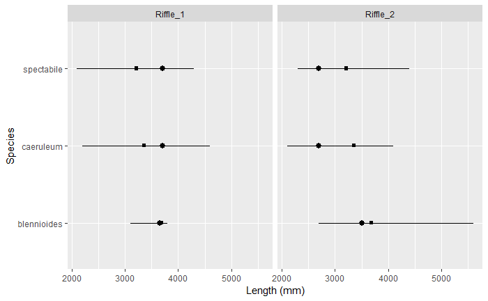

```r
ggplot(data = tidy_darters2) +
  stat_summary(
    mapping = aes(x = species, y = length),
    fun.ymin = min,
    fun.ymax = max,
    fun.y = median
  ) +
  geom_point(data = darter_means, mapping = aes(x = species, y = length_mean), shape = 15) +
  coord_flip() +
    facet_wrap(~ riffle) +
   ylab("Length (mm)") + xlab("Species")
```

Chunk represents darter plot 2.

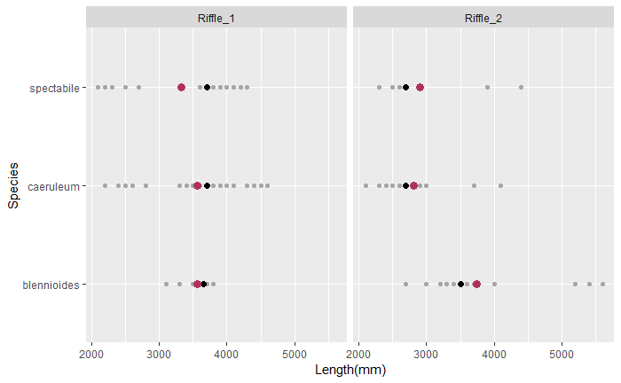

```r
ggplot(data = tidy_darters2, mapping = aes(x = species, y = length)) +
  geom_point(color = "gray65") +
  stat_summary(
    fun.ymin = min,
    fun.ymax = max,
    fun.y = median,
    geom = "point",
    size = 2.2
  ) +
  stat_summary(
    fun.ymin = min,
    fun.ymax = max,
    fun.y = mean,
    size = 3,
    geom = "point",
    color = "maroon"
  ) +
  coord_flip() +
  facet_wrap(~riffle) +
  xlab("Species") + ylab("Length(mm)")
```

Stress and Cortisone

```r
names <- c("capture_date", "day", "site", "urban_score", "cortF", "cortB", "sex", "smi", "tarsus", "mass", "basal_cort", "stress_cort")
file_path <- "C:\\Misc. Files\\BI485 Folder\\Kleinberg_Donovan\\data"
tidy_stress <- read_csv(file.path(file_path, "feathers.csv"), locale = locale(decimal_mark = ","), skip = 1, col_names = names)
tidy_stress
```

| capture_date | day | site | urban_score | cortF | cortB | sex | smi | tarsus | mass | basal_cort | stress_cort |
| --- | --- | --- | --- | --- | --- | --- | --- | --- | --- | --- | --- |
| 25/06/2013 | 176 | CEBC | -2.50 | 66.48 | 6.32 | M | 26.1 | 18.4 | 26.7 | 1.69 | 27.76 |
| 11/07/2013 | 192 | CEBC | -2.50 | 55.97 | 5.45 | F | 24.5 | 17.5 | 22.8 | 1.31 | 33.66 |
| 19/07/2013 | 200 | CEBC | -2.50 | 44.96 | 4.26 | F | 25.1 | 18.4 | 25.7 | 3.27 | 17.48 |
| 22/07/2013 | 203 | CEBC | -2.50 | 55.48 | 4.99 | M | 26.6 | 18.0 | 26.1 | 0.01 | 16.87 |
| 22/07/2013 | 203 | CEBC | -2.50 | 62.60 | 5.41 | M | 23.9 | 18.2 | 23.9 | 0.45 | 21.45 |
| 22/07/2013 | 203 | CEBC | -2.50 | 82.80 | 8.28 | M | 24.2 | 18.2 | 24.2 | 0.55 | 17.36 |
| 05/08/2013 | 217 | CEBC | -2.50 | 50.62 | 4.49 | F | 26.5 | 18.1 | 26.3 | NA | 30.91 |
| 05/08/2013 | 217 | CEBC | -2.50 | 35.27 | 3.17 | M | 23.7 | 18.8 | 25.2 | NA | NA |
| 13/08/2013 | 225 | CEBC | -2.50 | 44.39 | 4.23 | F | 25.8 | 18.5 | 26.7 | 1.23 | 25.24 |
| 13/08/2013 | 225 | CEBC | -2.50 | 45.16 | 4.75 | M | 25.7 | 18.1 | 25.5 | 0.96 | 18.12 |

[output cut: 33 more lines]

Chunk creates mean tarsus

```r
mean_tarsus <- mean(tidy_stress[["tarsus"]])
mean_tarsus
```

```
[1] 18.17907
```

Chunk adds log_mass and log_tarsus

```r
tidy_stress <- mutate(tidy_stress, log_mass = log(mass), log_tarsus = log(tarsus))
tidy_stress
```

| capture_date | day | site | urban_score | cortF | cortB | sex | smi | tarsus | mass | basal_cort | stress_cort | log_mass | log_tarsus |
| --- | --- | --- | --- | --- | --- | --- | --- | --- | --- | --- | --- | --- | --- |
| 25/06/2013 | 176 | CEBC | -2.50 | 66.48 | 6.32 | M | 26.1 | 18.4 | 26.7 | 1.69 | 27.76 | 3.284664 | 2.912351 |
| 11/07/2013 | 192 | CEBC | -2.50 | 55.97 | 5.45 | F | 24.5 | 17.5 | 22.8 | 1.31 | 33.66 | 3.126761 | 2.862201 |
| 19/07/2013 | 200 | CEBC | -2.50 | 44.96 | 4.26 | F | 25.1 | 18.4 | 25.7 | 3.27 | 17.48 | 3.246491 | 2.912351 |
| 22/07/2013 | 203 | CEBC | -2.50 | 55.48 | 4.99 | M | 26.6 | 18.0 | 26.1 | 0.01 | 16.87 | 3.261935 | 2.890372 |
| 22/07/2013 | 203 | CEBC | -2.50 | 62.60 | 5.41 | M | 23.9 | 18.2 | 23.9 | 0.45 | 21.45 | 3.173878 | 2.901422 |
| 22/07/2013 | 203 | CEBC | -2.50 | 82.80 | 8.28 | M | 24.2 | 18.2 | 24.2 | 0.55 | 17.36 | 3.186353 | 2.901422 |
| 05/08/2013 | 217 | CEBC | -2.50 | 50.62 | 4.49 | F | 26.5 | 18.1 | 26.3 | NA | 30.91 | 3.269569 | 2.895912 |
| 05/08/2013 | 217 | CEBC | -2.50 | 35.27 | 3.17 | M | 23.7 | 18.8 | 25.2 | NA | NA | 3.226844 | 2.933857 |
| 13/08/2013 | 225 | CEBC | -2.50 | 44.39 | 4.23 | F | 25.8 | 18.5 | 26.7 | 1.23 | 25.24 | 3.284664 | 2.917771 |
| 13/08/2013 | 225 | CEBC | -2.50 | 45.16 | 4.75 | M | 25.7 | 18.1 | 25.5 | 0.96 | 18.12 | 3.238678 | 2.895912 |

[output cut: 33 more lines]

Chunk runs the sma function along with summaries.

```r
major_axis <- sma(log_mass ~ log_tarsus, data = tidy_stress)
summary(major_axis)
```

```
Call: sma(formula = log_mass ~ log_tarsus, data = tidy_stress)

Fit using Standardized Major Axis

------------------------------------------------------------
Coefficients:
             elevation    slope
estimate    -2.2061196 1.864889
lower limit -3.5801826 1.450317
upper limit -0.8320566 2.397966

H0 : variables uncorrelated
R-squared : 0.3510553
P-value : 2.8406e-05
```

Chunk has coefficent.

```r
coef(major_axis)
```

```
elevation     slope
-2.206120  1.864889
```

```r
b <- 1.864889
```

Chunk adds new_smi

```r
tidy_stress <- mutate(tidy_stress, new_smi = mass * (mean_tarsus / tarsus) ^ b)
tidy_stress
```

| capture_date | day | site | urban_score | cortF | cortB | sex | smi | tarsus | mass | basal_cort | stress_cort | log_mass | log_tarsus | new_smi |
| --- | --- | --- | --- | --- | --- | --- | --- | --- | --- | --- | --- | --- | --- | --- |
| 25/06/2013 | 176 | CEBC | -2.50 | 66.48 | 6.32 | M | 26.1 | 18.4 | 26.7 | 1.69 | 27.76 | 3.284664 | 2.912351 | 26.10524 |
| 11/07/2013 | 192 | CEBC | -2.50 | 55.97 | 5.45 | F | 24.5 | 17.5 | 22.8 | 1.31 | 33.66 | 3.126761 | 2.862201 | 24.47756 |
| 19/07/2013 | 200 | CEBC | -2.50 | 44.96 | 4.26 | F | 25.1 | 18.4 | 25.7 | 3.27 | 17.48 | 3.246491 | 2.912351 | 25.12752 |
| 22/07/2013 | 203 | CEBC | -2.50 | 55.48 | 4.99 | M | 26.6 | 18.0 | 26.1 | 0.01 | 16.87 | 3.261935 | 2.890372 | 26.58630 |
| 22/07/2013 | 203 | CEBC | -2.50 | 62.60 | 5.41 | M | 23.9 | 18.2 | 23.9 | 0.45 | 21.45 | 3.173878 | 2.901422 | 23.84877 |
| 22/07/2013 | 203 | CEBC | -2.50 | 82.80 | 8.28 | M | 24.2 | 18.2 | 24.2 | 0.55 | 17.36 | 3.186353 | 2.901422 | 24.14813 |
| 05/08/2013 | 217 | CEBC | -2.50 | 50.62 | 4.49 | F | 26.5 | 18.1 | 26.3 | NA | 30.91 | 3.269569 | 2.895912 | 26.51466 |
| 05/08/2013 | 217 | CEBC | -2.50 | 35.27 | 3.17 | M | 23.7 | 18.8 | 25.2 | NA | NA | 3.226844 | 2.933857 | 23.67004 |
| 13/08/2013 | 225 | CEBC | -2.50 | 44.39 | 4.23 | F | 25.8 | 18.5 | 26.7 | 1.23 | 25.24 | 3.284664 | 2.917771 | 25.84271 |
| 13/08/2013 | 225 | CEBC | -2.50 | 45.16 | 4.75 | M | 25.7 | 18.1 | 25.5 | 0.96 | 18.12 | 3.238678 | 2.895912 | 25.70813 |

[output cut: 33 more lines]

Discussion for new_smi: The new column now extends to 5 decimal places instead of only one decimal place in the old column.

Chunk groups by site.

```r
tidy_stress %>%
  group_by(site)
```

| capture_date | day | site | urban_score | cortF | cortB | sex | smi | tarsus | mass | basal_cort | stress_cort | log_mass | log_tarsus | new_smi |
| --- | --- | --- | --- | --- | --- | --- | --- | --- | --- | --- | --- | --- | --- | --- |
| 25/06/2013 | 176 | CEBC | -2.50 | 66.48 | 6.32 | M | 26.1 | 18.4 | 26.7 | 1.69 | 27.76 | 3.284664 | 2.912351 | 26.10524 |
| 11/07/2013 | 192 | CEBC | -2.50 | 55.97 | 5.45 | F | 24.5 | 17.5 | 22.8 | 1.31 | 33.66 | 3.126761 | 2.862201 | 24.47756 |
| 19/07/2013 | 200 | CEBC | -2.50 | 44.96 | 4.26 | F | 25.1 | 18.4 | 25.7 | 3.27 | 17.48 | 3.246491 | 2.912351 | 25.12752 |
| 22/07/2013 | 203 | CEBC | -2.50 | 55.48 | 4.99 | M | 26.6 | 18.0 | 26.1 | 0.01 | 16.87 | 3.261935 | 2.890372 | 26.58630 |
| 22/07/2013 | 203 | CEBC | -2.50 | 62.60 | 5.41 | M | 23.9 | 18.2 | 23.9 | 0.45 | 21.45 | 3.173878 | 2.901422 | 23.84877 |
| 22/07/2013 | 203 | CEBC | -2.50 | 82.80 | 8.28 | M | 24.2 | 18.2 | 24.2 | 0.55 | 17.36 | 3.186353 | 2.901422 | 24.14813 |
| 05/08/2013 | 217 | CEBC | -2.50 | 50.62 | 4.49 | F | 26.5 | 18.1 | 26.3 | NA | 30.91 | 3.269569 | 2.895912 | 26.51466 |
| 05/08/2013 | 217 | CEBC | -2.50 | 35.27 | 3.17 | M | 23.7 | 18.8 | 25.2 | NA | NA | 3.226844 | 2.933857 | 23.67004 |
| 13/08/2013 | 225 | CEBC | -2.50 | 44.39 | 4.23 | F | 25.8 | 18.5 | 26.7 | 1.23 | 25.24 | 3.284664 | 2.917771 | 25.84271 |
| 13/08/2013 | 225 | CEBC | -2.50 | 45.16 | 4.75 | M | 25.7 | 18.1 | 25.5 | 0.96 | 18.12 | 3.238678 | 2.895912 | 25.70813 |

[output cut: 33 more lines]

Chunk calculates mean and se

```r
mean_basal_cort <- mean(tidy_stress$basal_cort, na.rm = TRUE)
mean_stress_cort <- mean(tidy_stress$stress_cort, na.rm = TRUE)
sd_basal_cort <- sd(tidy_stress$basal_cort, na.rm = TRUE)
sd_stress_cort <- sd(tidy_stress$stress_cort, na.rm = TRUE)
se_basal_cort <- sd_basal_cort/(sqrt(43))
se_stress_cort <- sd_stress_cort/(sqrt(43))
```

Plot 1

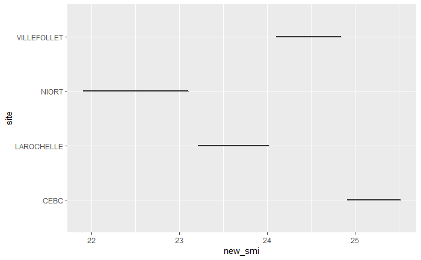

```r
ggplot(data = tidy_stress, mapping = aes(x = new_smi, y = site)) +
  geom_boxplot()
```

Discussion for plot 1: Yes, there are some very obvious differences between the sites. CEBC has the hights smi at over 25, Larochelle and Villefollet fall behind and Niort has the lowest ranging betewen 22 and 23.

Plot 2

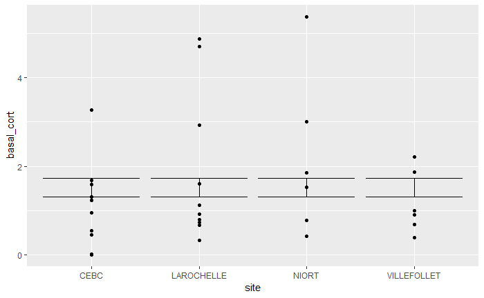

```r
min_basal <- mean_basal_cort - se_basal_cort
max_basal <- mean_basal_cort + se_basal_cort
ggplot(data = tidy_stress, mapping = aes(x = site, y = basal_cort)) +
  geom_point() +
  geom_errorbar(ymin = min_basal, ymax = max_basal)
```

Plot 3

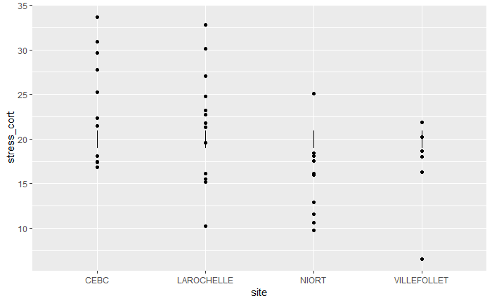

```r
min_stress <- mean_stress_cort - se_stress_cort
max_stress <- mean_stress_cort + se_stress_cort
ggplot(data = tidy_stress, mapping = aes(x = site, y = stress_cort)) +
  geom_point() +
  geom_linerange(ymin = min_stress, ymax = max_stress)
```